# PortfolioAnalytics Tutorial

May 19, 2017

## Overview

- Discuss Portfolio Optimization
- Introduce PortfolioAnalytics
- Demonstrate PortfolioAnalytics with Examples

## Modern Portfolio Theory

"Modern" Portfolio Theory (MPT) was introduced by Harry Markowitz in 1952.

In general, MPT states that an investor's objective is to maximize portfolio expected return for a given amount of risk.

Common Objectives

- Maximize a measure of gain per unit measure of risk
- Minimize a measure of risk

How do we define risk? What about more complex objectives and constraints?

## Portfolio Optimization Objectives

- Minimize Risk
  - Volatility, Tail Loss (VaR, ES), Max Drawdown, etc.
- Maximize Risk Adjusted Return
  - Sharpe Ratio, Information Ratio, etc.
- Risk Budgets
  - Equal Component Contribution to Risk (i.e. Risk Parity)
  - Limits on Component Contribution
- Maximize a Utility Function
  - Quadratic, Constant Relative Risk Aversion (CRRA), etc.
- Minimize Tracking Error
  - Replicating portfolio to track an index or basket of assets

## Challenges of Portfolio Optimization in R

- Many solvers are not specific to portfolio optimization
- Understanding the capabilities and limits of solvers to select the appropriate solver for the problem or formulate the problem to fit the solver.
- Lack of a common interface to a wide range of solvers in R, difficult to switch between solvers.
- Closed-Form vs. Global Solvers

## PortfolioAnalytics Overview

PortfolioAnalytics is an R package designed to provide numerical solutions and visualizations for portfolio optimization problems with complex constraints and objectives.

Supports:

- multiple constraint and objective types
- modular constraints and objectives
- an objective function can be any valid R function
- user defined moment functions (e.g. covariance matrix, return projections)
- visualizations
- solver agnostic
- parallel computing

## PortfolioAnalytics Framework

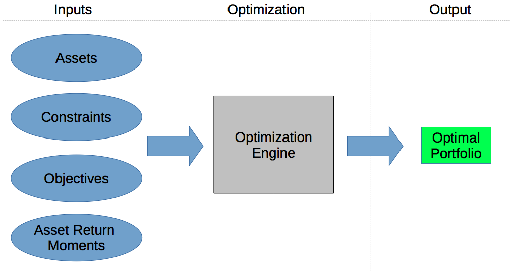

## Workflow: Specify Portfolio

```r
p <- portfolio.spec(assets = c('AAPL', 'MSFT', 'GOOG'))
print(p)
```

```
## PortfolioAnalytics Portfolio Specification
##
## Call:
## portfolio.spec(assets = c("AAPL", "MSFT", "GOOG"))
##
## Number of assets: 3
## Asset Names
## [1] "AAPL" "MSFT" "GOOG"
```

Initializes the portfolio object that holds portfolio level data, constraints, and objectives

## Workflow: Add Constraints

```r
# weights sum to 1
p <- add.constraint(portfolio = p, type = 'weight_sum',
                    min_sum = 1, max_sum = 1)
# special type for full investment constraint
# add.constraint(portfolio = p, type = 'full_investment')
# box constraints
p <- add.constraint(portfolio = p, type = 'box',
                    min = 0.2, max = 0.6)
```

Supported Constraint Types

- Sum of Weights
- Box, Group
- Factor Exposure
- Position Limit
- and many more

## Workflow: Add Objectives

```r
p <- add.objective(portfolio = p, type = 'risk', name = 'StdDev')
```

Supported Objective types

- Return
- Risk
- Risk Budget
- Weight Concentration

## Workflow: Run Optimization

```r
opt <- optimize.portfolio(R, portfolio=p, optimize_method='random',
                          search_size=2000)

opt.rebal <- optimize.portfolio.rebalancing(R, portfolio=p,
                                            optimize_method='random',
                                            search_size=2000,
                                            rebalance_on='quarters',
                                            training_period=60,
                                            rolling_window=60)
```

## Workflow: Analyze Results

| Visualization | Data Extraction |
| --- | --- |
| plot | extractObjectiveMeasures |
| chart.Concentration | extractStats |
| chart.EfficientFrontier | extractWeights |
| chart.RiskReward | print |
| chart.RiskBudget | summary |
| chart.Weights |  |

## Support Multiple Solvers

Linear and Quadratic Programming Solvers

- R Optimization Infrastructure (ROI)
  - GLPK (Rglpk)
  - Symphony (Rsymphony)
  - Quadprog (quadprog)

Global Solvers

- Random Portfolios
- Differential Evolution (DEoptim)
- Particle Swarm Optimization (pso)
- Generalized Simulated Annealing (GenSA)

## Random Portfolios

PortfolioAnalytics has three methods to generate random portfolios.

1. The **sample** method to generate random portfolios is based on an idea by Pat Burns.
2. The **simplex** method to generate random portfolios is based on a paper by W. T. Shaw.
3. The **grid** method to generate random portfolios is based on the `gridSearch` function in the NMOF package.

## Random Portfolios: Simplex Method

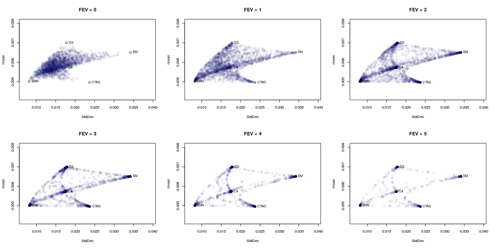

## Hierarchical (i.e. Multilayer) Optimization

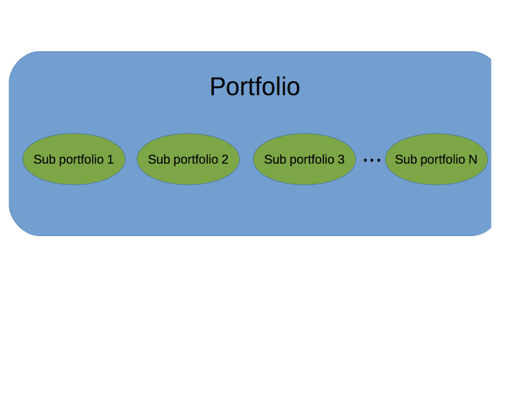

see [PortfolioAnalytics Tutorial R/Finance 2016](https://github.com/rossb34/PortfolioAnalyticsPresentation2016)

## Regime Switching Model

- Define a model to characterize `n` regimes
- Define `n` portfolio specifications, 1 for each regime

see [PortfolioAnalytics Tutorial R/Finance 2016](https://github.com/rossb34/PortfolioAnalyticsPresentation2016)

## Estimating Moments

Ledoit and Wolf (2003):

> "The central message of this paper is that nobody should be using the sample covariance matrix for the purpose of portfolio optimization."
- Sample
- Shrinkage Estimators
- Factor Model
- Expressing Views
  - [PortfolioAnalytics Tutorial R/Finance 2015](https://github.com/rossb34/PortfolioAnalyticsPresentation2015)
- See [Custom Moment and Objective Functions](https://cran.r-project.org/web/packages/PortfolioAnalytics/vignettes/custom_moments_objectives.pdf) vignette

## Example: U.S. Equity Sector ETF Portfolio

Consider a long only U.S. Equity portfolio allocation problem. Goal is to outperform the S&P 500 (SPY as a proxy).

Data

- Monthly returns of 9 U.S. Equity Sector ETFs from 1999 to May 2016 (Source: Yahoo)

Approach

- Baseline portfolio
- Box constraints
- Custom objective function
- Analysis

## Baseline Portfolio Specification

Baseline portfolio specification to minimize portfolio standard deviation, subject to full investment and long only constraints.

```r
# base portfolio specification
rp.seq <- generatesequence(min = 0, max = 1, by = 0.002)
p <- portfolio.spec(assets = colnames(R),
                    weight_seq = rp.seq)
p <- add.constraint(portfolio = p, type = 'weight_sum',
                    min_sum = 0.99, max_sum = 1.01)
p <- add.constraint(portfolio = p, type = 'box', min = 0, max = 1)
p <- add.objective(portfolio = p, type = 'return', name = 'mean',
                   multiplier = 0)
p <- add.objective(portfolio = p, type = 'risk', name = 'StdDev')
```

## Box Constraints

Add box constraints such that for each asset the minimum weight is 5% and the maximum weight is 20%.

- copy the baseline portfolio specification
- replace the second index of the constraint object

```r
# portfolio specification with box constraints
p.box <- p
p.box <- add.constraint(portfolio = p.box, type = 'box',
                        min = 0.05, max = 0.20, indexnum = 2)
```

## Single Period Optimization

Run a single period optimization for the portfolio specifications

```r
# generate the random portfolios
rp <- random_portfolios(portfolio = p, permutations = rp.n,
                        method = 'sample')
rp <- normalize.weights(rp)
rp.box <- random_portfolios(portfolio = p.box, permutations = rp.n,
                            method = 'sample')
rp.box <- normalize.weights(rp.box)

# run the optimizations
opt.base <- optimize.portfolio(R = tail(R, 36), portfolio = p,
                               rp = rp, optimize_method = 'random',
                               trace = TRUE)
opt.box <- optimize.portfolio(R = tail(R, 36), portfolio = p.box,
                              rp = rp.box, optimize_method = 'random',
                              trace = TRUE)
```

## Feasible Space Comparison

Impact of box constraints on the feasible space of the in sample period.

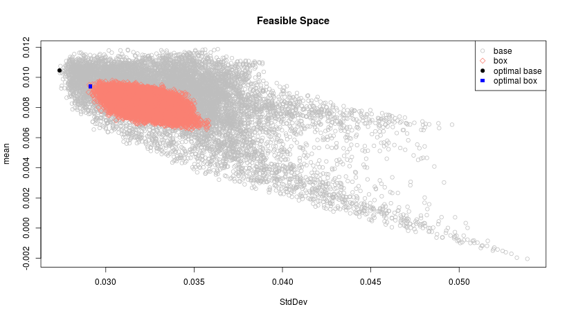

## Optimization with Periodic Rebalancing

```r
opt.base.rebal <- optimize.portfolio.rebalancing(R = R, portfolio = p,
                                                 optimize_method = 'random',
                                                 rp = rp, trace = TRUE,
                                                 rebalance_on = 'quarters',
                                                 training_period = 36,
                                                 rolling_window = 36)
opt.base.rebal.r <- Return.portfolio(R, weights = extractWeights(opt.base.rebal))
colnames(opt.base.rebal.r) <- 'base'

opt.box.rebal <- optimize.portfolio.rebalancing(R = R, portfolio = p.box,
                                                optimize_method = 'random',
                                                rp = rp.box, trace = TRUE,
                                                rebalance_on = 'quarters',
                                                training_period = 36,
                                                rolling_window = 36)
opt.box.rebal.r <- Return.portfolio(R, weights = extractWeights(opt.box.rebal))
colnames(opt.box.rebal.r) <- 'box'
```

## Baseline Optimal Weights

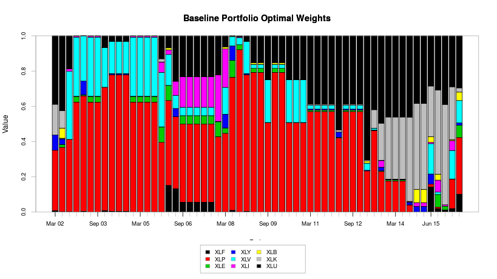

```r
chart.Weights(opt.base.rebal, main = 'Baseline Portfolio Optimal Weights')
```

## Box Constrained Optimal Weights

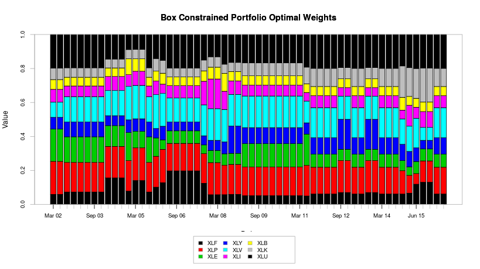

```r
chart.Weights(opt.box.rebal, main = 'Box Constrained Portfolio Optimal Weights')
```

## Baseline and Constrained

[figure not shown]

```r
opt.r <- cbind(opt.base.rebal.r, opt.box.rebal.r)
charts.PerformanceSummary(opt.r, main = "Performance Summary")
```

## Tracking Error Custom Objective Function

Define a custom objective function for penalized tracking error

```r
te.target <- function(R, weights, Rb, min.te = 0.02,
                      max.te = 0.05, scale = 12){
    r <- Return.portfolio(R = R, weights = weights)
    Rb <- Rb[index(r)]
    te <- sd(r - Rb) * sqrt(scale)
    # penalize tracking error outside of [min.te, max.te] range
    out <- 0
    if(te > max.te)
        out <- (te - max.te) * 10000
    if(te < min.te)
        out <- (min.te - te) * 10000
    out
}
```

## Tracking Error Target Optimization

- Add tracking error as an objective to the baseline portfolio specification
- Specify the arguments to `te.target` as a named list
- Target an Annualized Tracking Error in the range of 3% to 5%

```r
p.te <- p
p.te <- add.objective(portfolio = p, type = 'risk', name = 'te.target',
                      arguments = list(Rb = R.mkt, scale = 12,
                                       min.te = 0.03, max.te = 0.05))

opt.te.rebal <- optimize.portfolio.rebalancing(R = R, portfolio = p.te,
                                                optimize_method = 'random',
                                                rp = rp, trace = TRUE,
                                                rebalance_on = rebal.period,
                                                training_period = n.train,
                                                rolling_window = n.roll)
opt.te.rebal.r <- Return.portfolio(R, weights = extractWeights(opt.te.rebal))
colnames(opt.te.rebal.r) <- 'te.target'
```

## Tracking Error Target

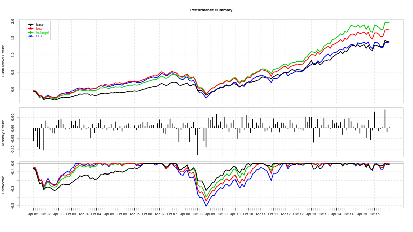

```r
opt.r <- na.omit(cbind(opt.base.rebal.r, opt.box.rebal.r,
                       opt.te.rebal.r, R.mkt))
charts.PerformanceSummary(opt.r, main = "Performance Summary")
```

## Portfolio Simulation and Analysis

- Random portfolios to simulate portfolios of zero skill managers
- Feasible portfolios by construction
- Monte Carlo requires a model specification
- Time series dependency with bootstrap
- No guarantee of a feasible portfolio with bootstrap or Monte Carlo Simulation

## Simulate Portfolio Returns

Simulate portfolio returns using the random portfolios generated from the baseline portfolio specification and box constrained portfolio specification.

```r
sim.base <- simulate.portfolio(R, rp = rp, simulations = 5000,
                               rebalance_on = 'quarters')
sim.box <- simulate.portfolio(R, rp = rp.box, simulations = 5000,
                              rebalance_on = 'quarters')
sim <- cbind(sim.box, sim.base)
charts.PerformanceSummary(sim, colorset = c(rep("salmon", ncol(sim.box)),
                                            rep('gray', ncol(sim.base))),
                          legend.loc = NULL, main = "Simulated Performance Summary")
legend('topleft', legend = c('constrained', 'unconstrained'),
       fill = c('salmon', 'gray'), bty = 'n')
```

## Simulated Portfolio

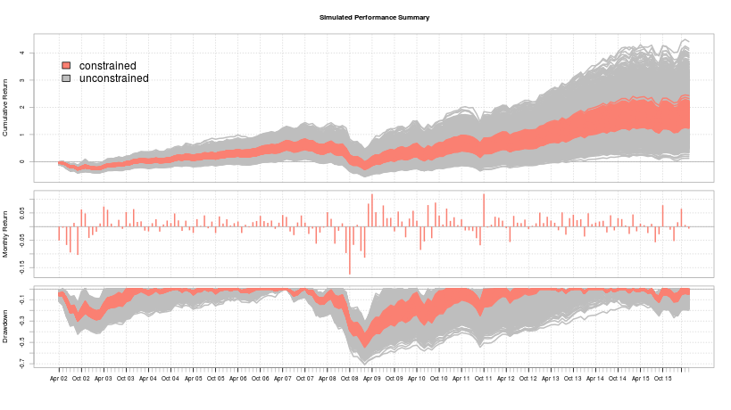

## Simulated vs. Optimal Portfolios: Sharpe Ratio Distribution

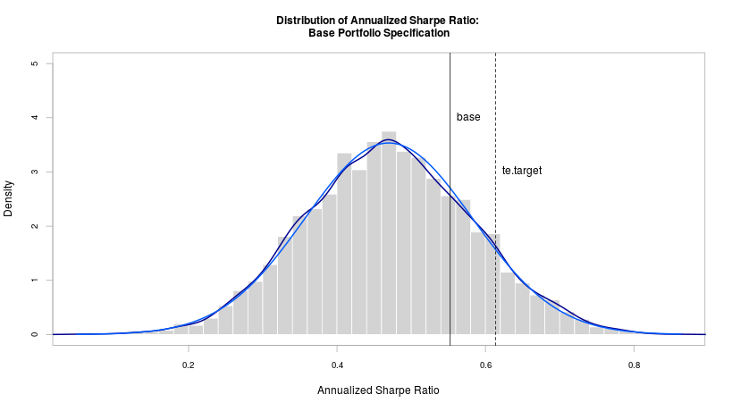

## Simulated vs. Optimal Portfolios: Sharpe Ratio Distribution

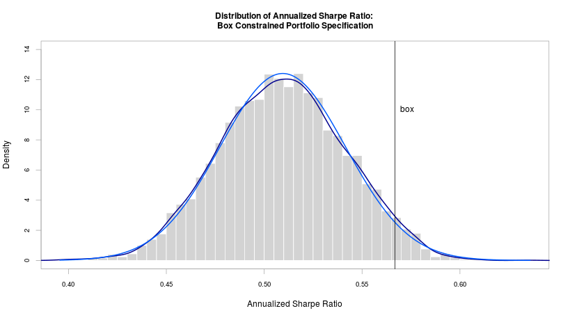

## Simulated vs. Optimal Portfolios: Tracking Error Distribution

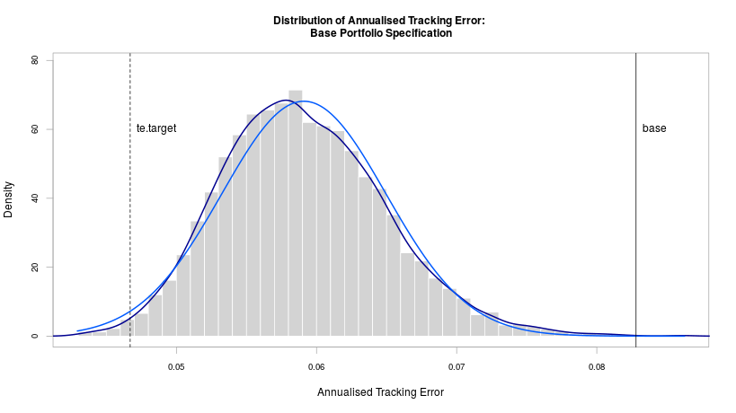

## Improvements

- Risk Measures
  - Expected Shortfall
  - Component contribution to risk (i.e. Risk Budgeting)
- Better Estimates
  - Factor Model
  - GARCH
  - Return Forecasts
- More Data
  - Weekly or daily frequency
    - downsampling to monthly frequency "throws away" a lot of data
  - Estimates based on higher frequency data

## Conclusion

- Introduced the goals and summary of PortfolioAnalytics
- Demonstrated the flexibility through examples
- Plans for continued development
  - Interface to \(parma\)
  - Additional solvers
  - Gallery of examples

#### Acknowledgements

- Google: funding Google Summer of Code (GSoC) for 2013 and 2014
- GSoC Mentors: Brian Peterson, Peter Carl, Doug Martin, and Guy Yollin
- R/Finance Committee

## PortfolioAnalytics Links

- [PortfolioAnalytics on CRAN](http://cran.at.r-project.org/web/packages/PortfolioAnalytics/index.html)
- [PortfolioAnalytics on GitHub](https://github.com/braverock/PortfolioAnalytics)

Source code for the slides

- https://github.com/rossb34/PortfolioAnalyticsPresentation2017

and view it here

- http://rossb34.github.io/PortfolioAnalyticsPresentation2017/

DataCamp Course

- https://www.datacamp.com/courses/intermediate-portfolio-analysis-in-r

## Any Questions?

## References and Useful Links

- [ROI](http://cran.r-project.org/web/packages/ROI/index.html)
- [DEoptim](http://cran.r-project.org/web/packages/DEoptim/index.html)
- [pso](http://cran.r-project.org/web/packages/pso/index.html)
- [GenSA](http://cran.r-project.org/web/packages/GenSA/index.html)
- [PerformanceAnalytics](http://cran.r-project.org/web/packages/PerformanceAnalytics/index.html)
- [Patrick Burns Random Portfolios](http://www.burns-stat.com/pages/Finance/randport_practice_theory_annotated.pdf)
- [W.T. Shaw Random Portfolios](http://papers.ssrn.com/sol3/papers.cfm?abstract_id=1856476)
- [Improved Forecasts of Higher-Order Co-moments and Implications for Portfolio Selection](http://docs.edhec-risk.com/EAID-2008-Doc/documents/Higher_Order_Comoments.pdf)
- [Higher Order Comoments of Multifactor Models and Asset Allocation](http://papers.ssrn.com/sol3/papers.cfm?abstract_id=2409603)